# Assignment 3

## Bank Marketing Case Study: Numerical attributes check

The head of Marketing wants to know which customers have the highest propensity for buying a Certificate of Deposit (CD) from the institution. The goal of this assignment is to check errors in numerical variables and correct them.

### Learning outcomes

- Use proc univariate to examine errors in numerical variables.
- Use binning to create derived variables.
- list the highest and lowest values for a numerical variable by percentage.

### 1. Examine the list of numerical attributes

Use proc means to list the numerical attributes and their descriptive statistics. use options n nmiss mean median min max maxdec=1

```sas
libname mylib '/folders/myfolders/assignments';
title "Descriptive statistics of numerical variables in the dataset";
proc means data=mylib.customer_all n nmiss mean median min max maxdec=1;
run;
```

Descriptive statistics of numerical variables in the dataset

The MEANS Procedure

| Variable | Label | N | N Miss | Mean | Median | Minimum | Maximum |
| --- | --- | --- | --- | --- | --- | --- | --- |
| customer_id day campaign pdays previous balance AGE | day campaign pdays previous AGE | 10578 10578 10578 10578 10578 10578 10558 | 0 0 0 0 0 0 20 | 127278.2 15.5 2.5 52.0 0.9 1548.5 41.3 | 130012.0 15.0 2.0 -1.0 0.0 566.0 39.0 | 100103.0 1.0 1.0 -1.0 0.0 -3058.0 18.0 | 145309.0 31.0 50.0 854.0 275.0 81204.0 146.0 |

Interpret:

- Observe the range of values for pdays. go to https://archive.ics.uci.edu/ml/datasets/bank+marketing and check what pdays stands for. what does -1 means?
- Examine the range of values for day. what does this variable refer to?
- Examine the column N Miss for the variable "age". are there missing values? how many ?

Answer here:

1. FROM UCI Repo: pdays: number of days that passed by after the client was last contacted from a previous campaign (numeric; 999 means client was not previously contacted). By doing data profiling, I think -1 means client was not previously contacted
2. Variable DAY contain integer value from 1 to 31. Base on the range of values for day, I can conclude day is the day part of actual date.
3. There are 20 missing values in the variable AGE

### 2. Examine the variable "age"

#### 2.1. use PROC UNIVARIATE to examine the numeric variable "age" by showing tabular and graphical information.

Running PROC UNIVARIATE on AGE

The UNIVARIATE Procedure

Variable: AGE (AGE)

| Moments |  |  |  |
| --- | --- | --- | --- |
| N | 10558 | Sum Weights | 10558 |
| Mean | 41.2641599 | Sum Observations | 435667 |
| Std Deviation | 12.1483452 | Variance | 147.582292 |
| Skewness | 1.00818411 | Kurtosis | 2.05204285 |
| Uncorrected SS | 19535459 | Corrected SS | 1558026.26 |
| Coeff Variation | 29.4404279 | Std Error Mean | 0.11822962 |

| Basic Statistical Measures Location | Basic Statistical Measures Location | Basic Statistical Measures Variability | Basic Statistical Measures Variability |
| --- | --- | --- | --- |
| Mean | 41.26416 | Std Deviation | 12.14835 |
| Median | 39.00000 | Variance | 147.58229 |
| Mode | 31.00000 | Range | 128.00000 |
|  |  | Interquartile Range | 17.00000 |

| Tests for Location: Mu0=0 Test | Tests for Location: Mu0=0 Statistic | Tests for Location: Mu0=0 Statistic | Tests for Location: Mu0=0 p Value | Tests for Location: Mu0=0 p Value |
| --- | --- | --- | --- | --- |
| Student's t | t | 349.0171 | Pr > \|t\| | <.0001 |
| Sign | M | 5279 | Pr >= \|M\| | <.0001 |
| Signed Rank | S | 27870481 | Pr >= \|S\| | <.0001 |

| Quantiles (Definition 5) Level | Quantiles (Definition 5) Quantile |
| --- | --- |
| 100% Max | 146 |
| 99% | 77 |
| 95% | 62 |
| 90% | 58 |
| 75% Q3 | 49 |
| 50% Median | 39 |
| 25% Q1 | 32 |
| 10% | 28 |
| 5% | 26 |
| 1% | 22 |
| 0% Min | 18 |

| Extreme Observations Lowest Value | Extreme Observations Lowest customer_id | Extreme Observations Lowest Obs | Extreme Observations Highest Value | Extreme Observations Highest customer_id | Extreme Observations Highest Obs |
| --- | --- | --- | --- | --- | --- |
| 18 | 144745 | 10273 | 95 | 141764 | 8550 |
| 18 | 143738 | 9679 | 130 | 120217 | 3490 |
| 18 | 143055 | 9240 | 139 | 107284 | 1152 |
| 18 | 142375 | 8880 | 144 | 109385 | 1531 |
| 18 | 141588 | 8455 | 146 | 102598 | 402 |

| Missing Values Missing Value | Missing Values Count | Missing Values Percent Of All Obs | Missing Values Percent Of Missing Obs |
| --- | --- | --- | --- |
| . | 20 | 0.19 | 100.00 |

Running PROC UNIVARIATE on AGE

The UNIVARIATE Procedure

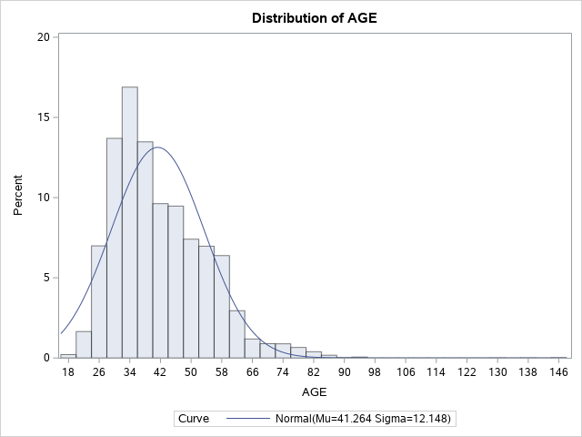

Running PROC UNIVARIATE on AGE

The UNIVARIATE Procedure

Fitted Normal Distribution for AGE (AGE)

| Parameters for Normal Distribution Parameter | Parameters for Normal Distribution Symbol | Parameters for Normal Distribution Estimate |
| --- | --- | --- |
| Mean | Mu | 41.26416 |
| Std Dev | Sigma | 12.14835 |

| Goodness-of-Fit Tests for Normal Distribution Test | Goodness-of-Fit Tests for Normal Distribution Statistic | Goodness-of-Fit Tests for Normal Distribution Statistic | Goodness-of-Fit Tests for Normal Distribution p Value | Goodness-of-Fit Tests for Normal Distribution p Value |
| --- | --- | --- | --- | --- |
| Kolmogorov-Smirnov | D | 0.106237 | Pr > D | <0.010 |
| Cramer-von Mises | W-Sq | 25.931403 | Pr > W-Sq | <0.005 |
| Anderson-Darling | A-Sq | 150.997380 | Pr > A-Sq | <0.005 |

| Quantiles for Normal Distribution Percent | Quantiles for Normal Distribution Quantile Observed | Quantiles for Normal Distribution Quantile Estimated |
| --- | --- | --- |
| 1.0 | 22.0000 | 13.0029 |
| 5.0 | 26.0000 | 21.2819 |
| 10.0 | 28.0000 | 25.6954 |
| 25.0 | 32.0000 | 33.0702 |
| 50.0 | 39.0000 | 41.2642 |
| 75.0 | 49.0000 | 49.4581 |
| 90.0 | 58.0000 | 56.8329 |
| 95.0 | 62.0000 | 61.2464 |
| 99.0 | 77.0000 | 69.5254 |

```sas
title "Running PROC UNIVARIATE on AGE";
proc univariate data=mylib.customer_all nextrobs=5;
   id customer_id;
   var age;
   histogram / normal;
run;
```

#### 2.2. write a piece of code to output the customer_id whose age is missing. Use the function missing within if statements

```sas
data customer_id_missing_age (keep = customer_id);
    set mylib.customer_all;
    if missing(age);
run;
title "Customer_id with missing age";
proc print data = customer_id_missing_age;
    id customer_id;
run;
```

Customer_id with missing age

| customer_id |
| --- |
| 100898 |
| 103782 |
| 104872 |
| 108581 |
| 112972 |
| 113317 |
| 114933 |
| 115167 |
| 117338 |
| 122821 |
| 127452 |
| 128062 |
| 128123 |
| 131745 |
| 134418 |
| 134663 |
| 135384 |
| 135695 |
| 143464 |
| 143512 |

#### 2.3. apply imputation to replace missing values for age with the mean age.

Name the imputed dataset as customer_all_Imputed.

For reference, use PROC STDIZE to replace missing values with mean.  
Here is a sample code:

```
/* Mean imputation: Use PROC STDIZE to replace missing values with mean */

proc stdize data=Have out=Imputed
      oprefix=Orig_         /* prefix for original variables */
      reponly               /* only replace; do not standardize */
      method=MEAN;          /* or MEDIAN, MINIMUM, MIDRANGE, etc. */
   var Height;              /* you can list multiple variables to impute */
run;

proc print data=Imputed;
   format Orig_Height Height BESTD8.1;
   var Name Orig_Height Height Weight Replaced;
run;
```

```sas
proc stdize data=mylib.customer_all out=mylib.customer_all_Imputed
      oprefix=Orig_         /* prefix for original variables */
      reponly               /* only replace; do not standardize */
      method=MEAN;          /* or MEDIAN, MINIMUM, MIDRANGE, etc. */
   var age;              /* you can list multiple variables to impute */
run;

title "customer_id with imputed age using mean";
proc print data=mylib.customer_all_Imputed;
   var customer_id Orig_age age;
   where missing(orig_age);
run;
```

customer_id with imputed age using mean

| Obs | customer_id | Orig_AGE | AGE |
| --- | --- | --- | --- |
| 120 | 100898 | . | 41 |
| 593 | 103782 | . | 41 |
| 785 | 104872 | . | 41 |
| 1384 | 108581 | . | 41 |
| 2130 | 112972 | . | 41 |
| 2191 | 113317 | . | 41 |
| 2507 | 114933 | . | 41 |
| 2550 | 115167 | . | 41 |
| 2978 | 117338 | . | 41 |
| 3990 | 122821 | . | 41 |
| 4842 | 127452 | . | 41 |
| 4947 | 128062 | . | 41 |
| 4955 | 128123 | . | 41 |
| 5795 | 131745 | . | 41 |
| 6551 | 134418 | . | 41 |
| 6611 | 134663 | . | 41 |
| 6738 | 135384 | . | 41 |
| 6796 | 135695 | . | 41 |
| 9511 | 143464 | . | 41 |
| 9539 | 143512 | . | 41 |

#### 2.4. use proc means to check the list of numerical attributes in customer_all_Imputed

make sure there is no missing value for the variable age.

```sas
libname mylib '/folders/myfolders/assignments';
title "Descriptive statistics of numerical variables age-imputed dataset";
proc means data=mylib.customer_all_imputed n nmiss mean median min max maxdec=1;
run;
```

Descriptive statistics of numerical variables age-imputed dataset

The MEANS Procedure

| Variable | Label | N | N Miss | Mean | Median | Minimum | Maximum |
| --- | --- | --- | --- | --- | --- | --- | --- |
| customer_id day campaign pdays previous balance Orig_AGE AGE | day campaign pdays previous AGE AGE | 10578 10578 10578 10578 10578 10578 10558 10578 | 0 0 0 0 0 0 20 0 | 127278.2 15.5 2.5 52.0 0.9 1548.5 41.3 41.3 | 130012.0 15.0 2.0 -1.0 0.0 566.0 39.0 39.0 | 100103.0 1.0 1.0 -1.0 0.0 -3058.0 18.0 18.0 | 145309.0 31.0 50.0 854.0 275.0 81204.0 146.0 146.0 |

**We can see that the number of missing value in new Age is 0, the Orig_age is 20.**

### 3. Does age have an influence on balance?

You may think to scatter plot age versus balance. Have a look! Ref: https://kb.iu.edu/d/bddo

It is hard to have a conclusion!

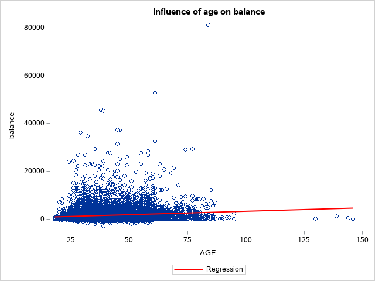

```sas
* use sgplot to draw a scatter plot and regression line ;
title 'Influence of age on balance';
proc sgplot data=mylib.customer_all;
reg x=age y=balance / lineattrs=(color=red thickness=2);
run;
```

#### 3.1. Binning

- discretize the variable age by creating a new cat variable named age_cat:

  ```
    18 <=AGE <=35 for young_adult,
    36 <=AGE <=55 for middle_age
    >56 for old.
  ```

- show a simple frequency table for age_cat

```sas
data mylib.customer_all_imputed_binned;
     set mylib.customer_all_imputed;
     format age_cat $15.;

     if age ge 18 and age le 35 then age_cat = 'young_adult';
     else if age le 55 then age_cat = 'middle_age';
     else  age_cat= 'old' ;
run;
title "Age_cat frequency table";
proc freq data=mylib.customer_all_imputed_binned;
    tables age_cat;
run;
```

Age_cat frequency table

The FREQ Procedure

| age_cat | Frequency | Percent | Cumulative Frequency | Cumulative Percent |
| --- | --- | --- | --- | --- |
| middle_age | 4977 | 47.05 | 4977 | 47.05 |
| old | 1438 | 13.59 | 6415 | 60.64 |
| young_adult | 4163 | 39.36 | 10578 | 100.00 |

#### Here is the code to create a bar chart of balance by age.

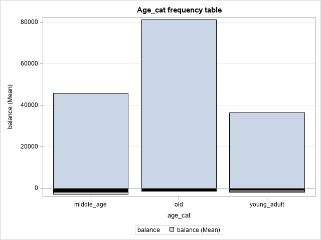

```sas
proc sgplot data=mylib.customer_all_imputed_binned;
    vbar age_cat / response=balance group=balance groupdisplay=cluster stat=mean;
    yaxis grid;
run;
```

#### 3.2. Which customers have the highest balance, young customers or older customers?

```
Answer: old customers (older than 55 years old)
```

### 4. Examine the variable campaign

campaign: number of contacts performed during this campaign and for this client (numeric, includes last contact)

#### 4.1. Use proc univariate on campaign.

Running PROC UNIVARIATE on Campaign

The UNIVARIATE Procedure

Variable: campaign (campaign)

| Moments |  |  |  |
| --- | --- | --- | --- |
| N | 10578 | Sum Weights | 10578 |
| Mean | 2.47475893 | Sum Observations | 26178 |
| Std Deviation | 2.61517814 | Variance | 6.83915672 |
| Skewness | 5.0976061 | Kurtosis | 44.6295296 |
| Uncorrected SS | 137122 | Corrected SS | 72337.7606 |
| Coeff Variation | 105.674056 | Std Error Mean | 0.02542726 |

| Basic Statistical Measures Location | Basic Statistical Measures Location | Basic Statistical Measures Variability | Basic Statistical Measures Variability |
| --- | --- | --- | --- |
| Mean | 2.474759 | Std Deviation | 2.61518 |
| Median | 2.000000 | Variance | 6.83916 |
| Mode | 1.000000 | Range | 49.00000 |
|  |  | Interquartile Range | 2.00000 |

| Tests for Location: Mu0=0 Test | Tests for Location: Mu0=0 Statistic | Tests for Location: Mu0=0 Statistic | Tests for Location: Mu0=0 p Value | Tests for Location: Mu0=0 p Value |
| --- | --- | --- | --- | --- |
| Student's t | t | 97.32702 | Pr > \|t\| | <.0001 |
| Sign | M | 5289 | Pr >= \|M\| | <.0001 |
| Signed Rank | S | 27976166 | Pr >= \|S\| | <.0001 |

| Quantiles (Definition 5) Level | Quantiles (Definition 5) Quantile |
| --- | --- |
| 100% Max | 50 |
| 99% | 14 |
| 95% | 7 |
| 90% | 5 |
| 75% Q3 | 3 |
| 50% Median | 2 |
| 25% Q1 | 1 |
| 10% | 1 |
| 5% | 1 |
| 1% | 1 |
| 0% Min | 1 |

| Extreme Observations Lowest Value | Extreme Observations Lowest customer_id | Extreme Observations Lowest Obs | Extreme Observations Highest Value | Extreme Observations Highest customer_id | Extreme Observations Highest Obs |
| --- | --- | --- | --- | --- | --- |
| 1 | 145305 | 10574 | 31 | 118202 | 3114 |
| 1 | 145304 | 10573 | 32 | 103432 | 543 |
| 1 | 145303 | 10572 | 37 | 110065 | 1643 |
| 1 | 145302 | 10571 | 43 | 113776 | 2276 |
| 1 | 145298 | 10569 | 50 | 118814 | 3214 |

Running PROC UNIVARIATE on Campaign

The UNIVARIATE Procedure

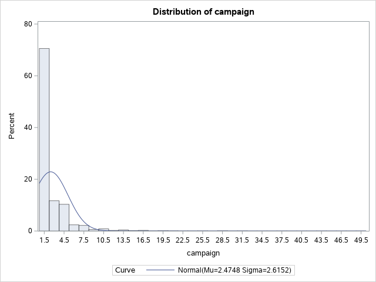

Running PROC UNIVARIATE on Campaign

The UNIVARIATE Procedure

Fitted Normal Distribution for campaign (campaign)

| Parameters for Normal Distribution Parameter | Parameters for Normal Distribution Symbol | Parameters for Normal Distribution Estimate |
| --- | --- | --- |
| Mean | Mu | 2.474759 |
| Std Dev | Sigma | 2.615178 |

| Goodness-of-Fit Tests for Normal Distribution Test | Goodness-of-Fit Tests for Normal Distribution Statistic | Goodness-of-Fit Tests for Normal Distribution Statistic | Goodness-of-Fit Tests for Normal Distribution p Value | Goodness-of-Fit Tests for Normal Distribution p Value |
| --- | --- | --- | --- | --- |
| Kolmogorov-Smirnov | D | 0.28640 | Pr > D | <0.010 |
| Cramer-von Mises | W-Sq | 228.76726 | Pr > W-Sq | <0.005 |
| Anderson-Darling | A-Sq | 1214.01226 | Pr > A-Sq | <0.005 |

| Quantiles for Normal Distribution Percent | Quantiles for Normal Distribution Quantile Observed | Quantiles for Normal Distribution Quantile Estimated |
| --- | --- | --- |
| 1.0 | 1.00000 | -3.60906 |
| 5.0 | 1.00000 | -1.82683 |
| 10.0 | 1.00000 | -0.87673 |
| 25.0 | 1.00000 | 0.71085 |
| 50.0 | 2.00000 | 2.47476 |
| 75.0 | 3.00000 | 4.23867 |
| 90.0 | 5.00000 | 5.82624 |
| 95.0 | 7.00000 | 6.77634 |
| 99.0 | 14.00000 | 8.55857 |

```sas
title "Running PROC UNIVARIATE on Campaign";
proc univariate data=mylib.customer_all nextrobs=5;
   id customer_id;
   var campaign;
   histogram / normal;
run;
```

#### 4.2. Interpret the quantiles table for the variable Campaign.

- The min value for campaign is 1.
- The first quartile is 1 means that 25% of the dataset have the value of campaign less than or equal to 1.
- The second quartile (median) is 2 means that 50% of the dataset have the value of campaign less than or equal to 2.
- The third quartile is 3 means that 75% of the dataset have the value of campaign less than or equal to 3.
- The max value for campaign is 50.

#### 4.3. Based on quantiles table, the variable campaign seems more categorical in nature than continuous.

Convert the variable campaign into a categorical variable name "campaign_cat" with ordinal values { 1, 2, 3, >3}

```sas
data mylib.customer_all_new;
     set mylib.customer_all_imputed_binned;
     format campaign_cat $3.;

     if campaign > 3 then campaign_cat = '>3';
     else campaign_cat = put(campaign, 3.);
run;
title "Campaign_cat frequency table";
proc freq data=mylib.customer_all_new;
    tables campaign_cat ;
run;
```

Campaign_cat frequency table

The FREQ Procedure

| campaign_cat | Frequency | Percent | Cumulative Frequency | Cumulative Percent |
| --- | --- | --- | --- | --- |
| 1 | 4556 | 43.07 | 4556 | 43.07 |
| 2 | 2907 | 27.48 | 7463 | 70.55 |
| 3 | 1237 | 11.69 | 8700 | 82.25 |
| >3 | 1878 | 17.75 | 10578 | 100.00 |

### 5. Examine the variable pdays

pdays: number of days that passed by after the client was last contacted from a previous campaign (numeric; -1 means client was not previously contacted)

#### 5.1. Use proc univariate on the variable pdays.

Running PROC UNIVARIATE on pdays

The UNIVARIATE Procedure

Variable: pdays (pdays)

| Moments |  |  |  |
| --- | --- | --- | --- |
| N | 10578 | Sum Weights | 10578 |
| Mean | 51.9548119 | Sum Observations | 549578 |
| Std Deviation | 109.347112 | Variance | 11956.791 |
| Skewness | 2.41099367 | Kurtosis | 6.46379989 |
| Uncorrected SS | 155020200 | Corrected SS | 126466978 |
| Coeff Variation | 210.465804 | Std Error Mean | 1.06317691 |

| Basic Statistical Measures Location | Basic Statistical Measures Location | Basic Statistical Measures Variability | Basic Statistical Measures Variability |
| --- | --- | --- | --- |
| Mean | 51.95481 | Std Deviation | 109.34711 |
| Median | -1.00000 | Variance | 11957 |
| Mode | -1.00000 | Range | 855.00000 |
|  |  | Interquartile Range | 50.00000 |

| Tests for Location: Mu0=0 Test | Tests for Location: Mu0=0 Statistic | Tests for Location: Mu0=0 Statistic | Tests for Location: Mu0=0 p Value | Tests for Location: Mu0=0 p Value |
| --- | --- | --- | --- | --- |
| Student's t | t | 48.86751 | Pr > \|t\| | <.0001 |
| Sign | M | -2577 | Pr >= \|M\| | <.0001 |
| Signed Rank | S | -2988344 | Pr >= \|S\| | <.0001 |

| Quantiles (Definition 5) Level | Quantiles (Definition 5) Quantile |
| --- | --- |
| 100% Max | 854 |
| 99% | 430 |
| 95% | 329 |
| 90% | 192 |
| 75% Q3 | 49 |
| 50% Median | -1 |
| 25% Q1 | -1 |
| 10% | -1 |
| 5% | -1 |
| 1% | -1 |
| 0% Min | -1 |

| Extreme Observations Lowest Value | Extreme Observations Lowest customer_id | Extreme Observations Lowest Obs | Extreme Observations Highest Value | Extreme Observations Highest customer_id | Extreme Observations Highest Obs |
| --- | --- | --- | --- | --- | --- |
| -1 | 145308 | 10577 | 805 | 145221 | 10526 |
| -1 | 145307 | 10576 | 828 | 144631 | 10217 |
| -1 | 145306 | 10575 | 831 | 144799 | 10299 |
| -1 | 145304 | 10573 | 842 | 144959 | 10396 |
| -1 | 145303 | 10572 | 854 | 144930 | 10380 |

Running PROC UNIVARIATE on pdays

The UNIVARIATE Procedure

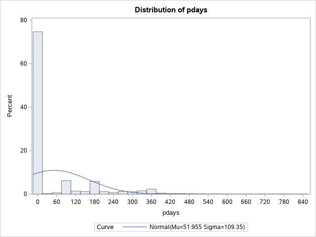

Running PROC UNIVARIATE on pdays

The UNIVARIATE Procedure

Fitted Normal Distribution for pdays (pdays)

| Parameters for Normal Distribution Parameter | Parameters for Normal Distribution Symbol | Parameters for Normal Distribution Estimate |
| --- | --- | --- |
| Mean | Mu | 51.95481 |
| Std Dev | Sigma | 109.3471 |

| Goodness-of-Fit Tests for Normal Distribution Test | Goodness-of-Fit Tests for Normal Distribution Statistic | Goodness-of-Fit Tests for Normal Distribution Statistic | Goodness-of-Fit Tests for Normal Distribution p Value | Goodness-of-Fit Tests for Normal Distribution p Value |
| --- | --- | --- | --- | --- |
| Kolmogorov-Smirnov | D | 0.42953 | Pr > D | <0.010 |
| Cramer-von Mises | W-Sq | 416.67946 | Pr > W-Sq | <0.005 |
| Anderson-Darling | A-Sq | 2042.95965 | Pr > A-Sq | <0.005 |

| Quantiles for Normal Distribution Percent | Quantiles for Normal Distribution Quantile Observed | Quantiles for Normal Distribution Quantile Estimated |
| --- | --- | --- |
| 1.0 | -1.00000 | -202.4246 |
| 5.0 | -1.00000 | -127.9052 |
| 10.0 | -1.00000 | -88.1792 |
| 25.0 | -1.00000 | -21.7987 |
| 50.0 | -1.00000 | 51.9548 |
| 75.0 | 49.00000 | 125.7083 |
| 90.0 | 192.00000 | 192.0888 |
| 95.0 | 329.00000 | 231.8148 |
| 99.0 | 430.00000 | 306.3342 |

```sas
title "Running PROC UNIVARIATE on pdays";
proc univariate data=mylib.customer_all_new nextrobs=5;
   id customer_id;
   var pdays;
   histogram / normal;
run;
```

#### 5.2. creating a derived variable

By checking the quantiles table in the proc univariate output, clearly it is better to create a new categorical variable named "contacted_before" that takes the value 'yes' if the customer has been contacted before and 'no' if the customer was not contacted before in a previous campaign (pdays=-1)

```sas
data mylib.customer_all_new1;
    set mylib.customer_all_new;
    format contacted_before $3.;
    if pdays = -1 then contacted_before = "no";
        else contacted_before = "yes";
run;

title "Frequency table for new contacted_before variable";
proc freq data = mylib.customer_all_new1;
    tables contacted_before;
run;
```

Frequency table for new contacted_before variable

The FREQ Procedure

| contacted_before | Frequency | Percent | Cumulative Frequency | Cumulative Percent |
| --- | --- | --- | --- | --- |
| no | 7866 | 74.36 | 7866 | 74.36 |
| yes | 2712 | 25.64 | 10578 | 100.00 |

#### 5.3. print the first 5 observations where pdays>0

```sas
title "First 5 observations where pdays>0";
proc print data = mylib.customer_all_new1 (obs = 5);
    where pdays>0;
run;
```

First 5 observations where pdays>0

| Obs | customer_id | contact | day | month | campaign | pdays | previous | poutcome | y | default | balance | housing | loan | Education | Orig_AGE | marital | JOB | AGE | age_cat | campaign_cat | contacted_before |
| --- | --- | --- | --- | --- | --- | --- | --- | --- | --- | --- | --- | --- | --- | --- | --- | --- | --- | --- | --- | --- | --- |
| 4210 | 124163 | telephone | 21 | oct | 1 | 166 | 1 | other | yes | no | -247 | yes | yes | secondary | 42 | single | admin. | 42 | middle_age | 1 | yes |
| 4211 | 124165 | telephone | 21 | oct | 1 | 91 | 4 | failure | yes | no | 3444 | yes | no | secondary | 33 | married | services | 33 | young_adult | 1 | yes |
| 4218 | 124178 | telephone | 23 | oct | 1 | 143 | 3 | failure | yes | no | 0 | yes | no | tertiary | 36 | married | management | 36 | middle_age | 1 | yes |
| 4221 | 124181 | unknown | 23 | oct | 1 | 147 | 2 | success | yes | no | 589 | yes | no | secondary | 56 | married | technician | 56 | old | 1 | yes |
| 4262 | 124237 | unknown | 6 | nov | 1 | 101 | 11 | other | no | no | 1770 | yes | no | tertiary | 34 | married | management | 34 | young_adult | 1 | yes |

#### 5.4. drop the column pdays

```sas
data mylib.customer_all_new;
    set mylib.customer_all_new1 (drop = pdays);
run;
```

[output not shown]

#### 5.5. use proc means and make sure pdays is not there

```sas
proc means data = mylib.customer_all_new;
run;
```

First 5 observations where pdays>0

The MEANS Procedure

| Variable | Label | N | Mean | Std Dev | Minimum | Maximum |
| --- | --- | --- | --- | --- | --- | --- |
| customer_id day campaign previous balance Orig_AGE AGE | day campaign previous AGE AGE | 10578 10578 10578 10578 10578 10558 10578 | 127278.17 15.4758934 2.4747589 0.8525241 1548.53 41.2641599 41.2641599 | 13660.22 8.4137946 2.6151781 3.4721156 3130.57 12.1483452 12.1368542 | 100103.00 1.0000000 1.0000000 0 -3058.00 18.0000000 18.0000000 | 145309.00 31.0000000 50.0000000 275.0000000 81204.00 146.0000000 146.0000000 |

### 6. Listing the 10 Highest and Lowest Values of balance

Refer to Chapter 4- data cleaning techniques for numeric data.

```sas
ods trace on;
title "List top 10 and bottom 10 values of balance";
ODS Select ExtremeObs;
proc univariate data=mylib.customer_all_new nextrobs=10;
   id customer_id;
   var balance;
run;
```

List top 10 and bottom 10 values of balance

The UNIVARIATE Procedure

Variable: balance

| Extreme Observations Lowest Value | Extreme Observations Lowest customer_id | Extreme Observations Lowest Obs | Extreme Observations Highest Value | Extreme Observations Highest customer_id | Extreme Observations Highest Obs |
| --- | --- | --- | --- | --- | --- |
| -3058 | 132814 | 6058 | 34646 | 120838 | 3616 |
| -1980 | 120418 | 3530 | 36252 | 134271 | 6501 |
| -1944 | 135493 | 6753 | 37378 | 102879 | 452 |
| -1781 | 119684 | 3396 | 37378 | 141898 | 8605 |
| -1668 | 115067 | 2532 | 45248 | 100547 | 71 |
| -1598 | 118222 | 3117 | 45789 | 115970 | 2726 |
| -1455 | 105635 | 888 | 52587 | 140864 | 8152 |
| -1379 | 106177 | 971 | 52587 | 143154 | 9321 |
| -1350 | 107068 | 1116 | 81204 | 142659 | 9037 |
| -1336 | 112813 | 2098 | 81204 | 143494 | 9526 |

```sas
Finish assignment 3!
```